# What is the effect of comparing Donald Trump to Hitler?

Original research

Dec 10, 2017 7 min read theory & empirics

Critics of U.S. President Donald Trump frequently [compare him to Adolf Hitler](http://amzn.to/2GJ0rsn). Does comparing Trump to Hitler decrease support for his policies? With the help of my students at the University of Southampton, we conducted a survey experiment to investigate the causal effect of a Hitler comparison on support for one of Trump's policies.

There are several reasons to expect that comparing Donald Trump to Adolf Hitler could decrease support for policies of the Trump administration. First of all, we know that people are very sensitive to how political questions are worded. Simply putting the word “Hitler” into a description of a policy could shift respondents’ attitudes towards the policy in a negative direction, for the simple reason that the former leader of the Third Reich has a ubiquitously negative connotation. Research on priming shows that exposing someone to the word “yellow” will make them more likely to think of a banana than an apple, for instance. Similarly, exposing someone to the word “Hitler”, could prime them to think of evil rather than good. There could also be a framing effect at work. Introducing Hitler to a respondents’ thought process could shift their frame of reference, pushing their estimate of The Donald closer to the far end of extreme evil. Finally, a comparison to Hitler could function as a piece of information that informs the respondent about something they did not previously know about Trump or the Trump administration.

While many critics of Trump assume the comparison to Nazism is a strong way to undermine his public support, there are also good reasons to believe comparisons to the infamous Nazi leader have no effect, or potentially even a positive effect on attitudes towards Trump’s policies. First, since the end of World War II, comparisons to Hitler for cheap rhetorical effect have become notoriously commonplace and abused. So-called Godwin’s Law suggests that “as an online discussion grows longer, the probability of a comparison involving Hitler approaches 1.” The overuse of comparisons to Hitler could leave this rhetorical tactic null and void to contemporary ears. Even more counter-intuitively, if respondents happen to really like Trump and his policies, then it could be possible for such analogies to actually increase support for the U.S. President's policies. This would be a theory of motivated reasoning. If you like Trump and his policies, then a comparison to Hitler could be experienced as a disruption to your psychological or emotional state, leading you to increase your support for The Donald's policies to counteract this threat to your mental state.

### Data and Method

To investigate the question empirically, we designed a web survey experiment that subjected respondents to two different framings of a controversial policy associated with the Trump administration. By randomly assigning respondents to two different framings of the policy and then asking all respondents their opinion about the policy, we can estimate the effect of the Hitler comparison by looking at the difference in the average opinion of these two groups. In particular, we asked respondents how they felt about a national registry for Muslims, a policy which has been associated with the Trump adminstration and which Trump has refused to disavow. In the weeks before the survey was conducted (on November 22, 2016), a wide variety of online media outlets published content explicitly comparing the policy to Nazi policy.

The respondents who were randomly assigned to a simple description of the policy (the control group), were given the following text:

> Some politicians in the United States have proposed a nationwide registry for all Muslims in the country. The purpose of the registry would be to identify, track, and surveil all Muslims in order to prevent terrorism.

The respondents who were randomly assigned to the treatment condition were given the same text but followed by an analogy to the infamous German leader and the Nazi regime in the run-up to the Holocaust:

> Some politicians in the United States have proposed a nationwide registry for all Muslims in the country. The purpose of the registry would be to identify, track, and surveil all Muslims in order to prevent terrorism. Critics have suggested this proposal is similar to how the Nazi regime built a registry to identify and track Jews before the Holocaust.

After respondents were given either the control or treatment text, they were presented with the following instructions: “On a scale from 0 to 100, use the sliding scale below to indicate your opinion about this proposal.” Below this was a visual slider-scale, set to 50 by default, with the left-hand side of the scale labeled “Strongly disagree,” the middle labeled “Neutral,” and the right-hand side labeled “Strongly agree.”

We used Amazon’s Mechanical Turk platform to hire 120 individuals to take the survey. While a representative sample of the United States population would be ideal, Mechanical Turk provides an efficient and affordable approach arguably superior to other options such as recruiting undergraduate students. Clearly the pool of Mechanical Turk workers are not a representative sample, and therefore our results will not generalize to any known population. Previous research has found that the pool of respondents obtained through Mechanical Turk constitutes a more broad cross-section of society than undergraduate student bodies, and therefore permits more generalization than permitted by studies based on undergraduate students. Mechanical Turk workers are from many countries around the world; the most represented country is the United States and the second most represented country is India. The United States President Donald Trump is likely to be fairly well known internationally so we see no especially compelling reason why international respondents should be excluded; still, given the American context of the research question, we checked the robustness of the results presented below when the data is subsetted to U.S. respondents only. The results do not change appreciably.

Given the very short length of our one-page, one-item survey, we expect respondents to complete the survey rather rapidly. Yet overly rapid responses are not credible. Before analysis, we removed all respondents who spent less than 10 seconds on the survey. Another issue is that we identifed a small number of respondents who submitted more than once. In such cases, we kept the first response and removed the duplicate(s). The results reported below do not change appreciably if we include the duplicates or remove all duplicates.

### Results

The resulting analytic sample consists of 95 observations. 48 respondents were assigned to the control group and 47 were assigned to the treatment group. The mean value of the dependent variable, support for a national registry, is 34.11 with a standard deviation of 38.86. Figure 1 displays a histogram of the distribution.

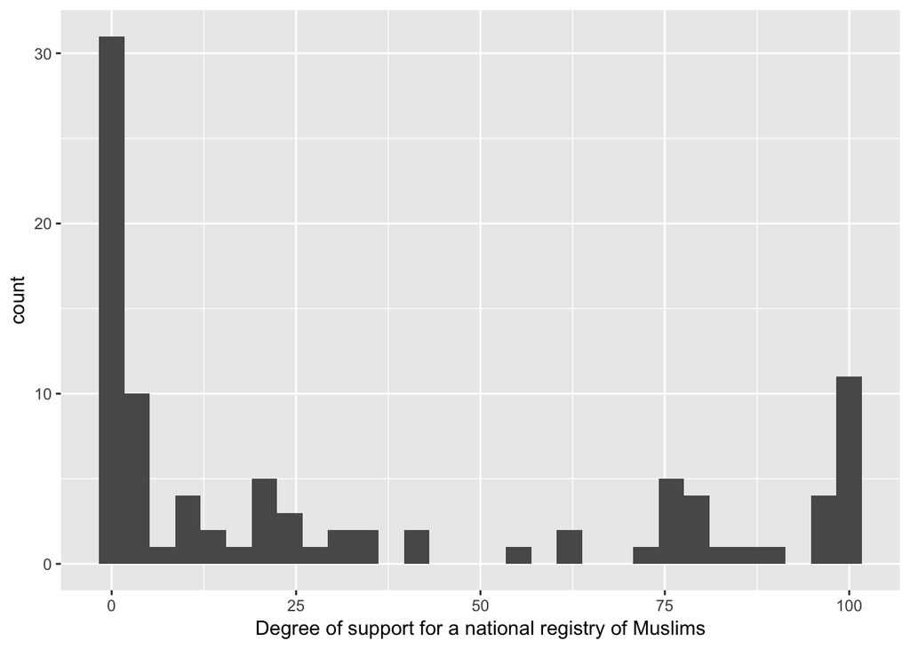

*Distribution of the dependent variable*

To estimate the effect of the treatment, we use a simple regression model. Table 1 displays the results. The coefficient for “Treatment” indicates the difference in the average value of the dependent variable between the control and treatment groups. A positive sign would indicate the treatment group reported greater support for a national registry, while a negative sign would indicate the treatment group reported less support for a national registry. The number below the coefficient, in parentheses, is the standard error.

|  | *Dependent variable:* |
| --- | --- |
|  | Support for a registry |
| Treatment | 3.287 |
|  | (8.011) |
| Constant | 32.479*** |
|  | (5.635) |
| Observations | 95 |
| R<sup>2</sup> | 0.002 |
| Adjusted R<sup>2</sup> | -0.009 |
| Residual Std. Error | 39.037 (df = 93) |
| F Statistic | 0.168 (df = 1; 93) |
| *Note:* | *p<0.1; **p<0.05; ***p<0.01 |

The results suggest that those exposed to the comparison were slightly more favorable toward the proposal for a national registry, but the difference is not statistically distinguishable from zero. The estimated effect, represented by the coefficient, is 3.29 but the probability of observing such a small difference due to chance alone is too great for us to infer that the treatment had any causal effect.

To better understand the result of the experiment, Figure 2 displays the expected support for a registry among the control and treatment groups. The horizontal blue lines indicate the means and the grey areas represent the 95% confidence intervals around each mean. The overlap of the two grey areas around roughly the same level of support indicates that comparing the policy of a national registry for muslims to Nazi policy had no observable effect on the respondents to our survey.

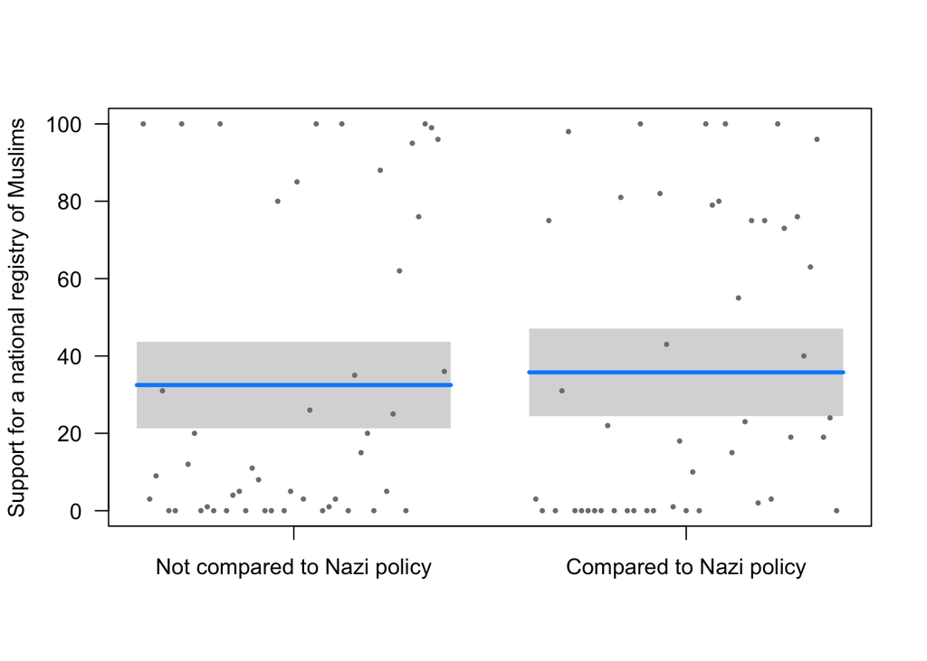

The Effect of a Hitler Comparison

### Conclusion

Our study suggests that comparisons to Adolf Hitler’s policies may not undermine support for particular public policies today. Future research should consider whether the effect of Hitler comparisons might be conditional on the political ideology or partisanship of the individual. Previous research suggests that conservatives or Republicans may respond to such analogies with increased support for President Trump and/or his administration's policies, whereas leftists or Democrats may respond with decreased support. A limitation of this study is that we did not measure ideology or partisanship so we could not explore this question. A future study should explore this possibility.

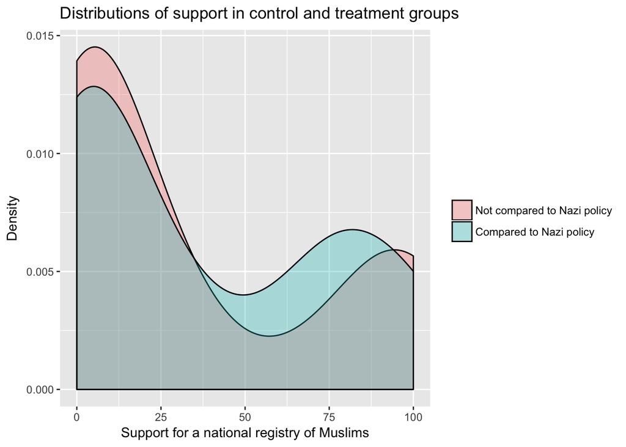

*Overlaid kernel density plots for treatment and control groups*

social science race media academic research

### Related

- Slides on 'Democracy' as propaganda for capitalism
- Are Americans becoming more conservative or liberal (right or left)?
- Milo, motivated reasoning, and the left-wing Fox News
- Social science and the radical politics of not knowing
- Graph of economic growth and democracy across countries over time

[comments powered by Disqus](https://disqus.com)